**CSE2215** - Computer Graphics

Elmar Eisemann, Ricardo Marroqium, Mathijs Molenaar

# Shading

This assignment focuses on the concepts behind various shading models (which define the appearance of an object’s surface) and the placement of lights (to illuminate these objects). You will learn about concepts such as Lambertian, Phong and Blinn-Phong shading, and you will build your own cartoon-like shader.

In modern graphics pipelines, we would write shaders, which are small programs to define these shading models efficiently, and are often run on the GPU. Today, however, we will work in a simulated framework allowing us to write these shaders on the CPU. The functions you will implement are called for each vertex, and the resulting color will be mapped on the model. There are many comments in the code to help you along, so read these carefully.

## Illumination models

To place the light at the current camera position press l. To add a second light, use L. Use the r, g, and b keys on your keyboard (in combination with shift) to change the color of the light. The implementation of the following exercises should go in `src/shading.cpp`.

### 1. Lambertian Model

First, we will define a simple diffuse surface shading. The basic formula for the Lambertian model is:
$$K_d (N \cdot L)$$

Here $K_d$ is the diffuse coefficient, $N$ is the normal vector at the current point, and $L$ is the direction from this point towards the light. Be careful that the result should not be negative: you may want to clamp values to 0. Be sure to read http://en.wikipedia.org/wiki/Lambertian_reflectance for more information, and look at the figure below for an example.

**Implement the Lambertian Model in the `diffuseOnly()` function in `shading.cpp`**

[figure not shown]

The Lambertian model

### 2. Phong Specularity Model

Second, we will implement the Phong specularity model, which introduces view-dependent effects called specularities. The basic formula for the Phong model is:
$$K_s (R \cdot V)^s$$

Here $K_s$ is the specularity coefficient, $R$ is the reflection vector (reflected vector from the light, at the plane, on the plane’s normal), $V$ is the view vector (from the surface point to the camera position), and $s$ is the specular exponent (the shininess, influencing the size of the highlight). Be careful with your implementation: a light placed behind the model should not illuminate it from the front!. Be sure to read [https://en.wikipedia.org/wiki/Phong_ reflection_model](https://en.wikipedia.org/wiki/Phong_%20reflection_model) for more information, and look at the following figure for an example.

**Implement the Phong model in the phongSpecularOnly() function in `shading.cpp`**

[figure not shown]

Specularity only

[figure not shown]

Diffuse and specular combined

### 3. Blinn-Phong Specularity Model

Third, we will implement the Blinn-Phong specularity model, which is similar to the Phong model above. The basic formula for the Blinn-Phong model is:
$$K_s (H \cdot N)^s$$

The difference here lies in the use of $N$ (the normal) and $H$, which is a half vector: the unit vector exactly between the view direction $V$ and the direction towards the light. Once more, make sure that a light placed behind the model does not illuminate it from the front. Be sure to look at the following figure for an example.

**Implement the Blinn-Phong model in the blinnPhongSpecularOnly() function in `shading.cpp`**

[figure not shown]

Specularity only

[figure not shown]

Diffuse and specular combined

### 4. Toon Shading

Now, we will implement toon shading, which gives the impression of looking at a comic drawing. To do this, all you need to do is to quantize the previously built illumination models. This we will do in two steps:

1. While normal diffuse shading has values between $0$ and $K_d$, in toon shading these are discretized. This means there are $n$ uniform intervals between $0$ and $K_d$. This means there are $n + 1$ boundary values $c$ for these intervals: $c(0) = 0, c(1), ..., c(n) = K_d$. Now, for a specific value v in $[c(i), c(i + 1))$ your implementation should return $(c(i) + c(i + 1))/2$.
2. With toon shading specularity, the goal is to add highlights. Given a threshold $t$, if blinn-phong specularity is larger or equal to $t$, return 1, else return 0.

Be sure ot look at the figure below for an example.

**Implement diffuse toon shading in `toonShadingNoSpecular()`. Then implement the specularities in `toonShadingOnlySpecular()`. Both should be implemented in `shading.cpp`.**

[figure not shown]

Diffuse only

[figure not shown]

Diffuse and specular combined

## And there was light!

Now, we will focus on the control of the illumination. For an artist, it can be difficult to control the light positions (just look at the credits of any modern movie, there are hundreds of people working on the light placements). Our goal is to simplify this work and provide the artist with a tool to efficiently place lights in an indirect manner. We will use the function `userInteraction()` in the following exercises. This function receives where the user has “clicked” (as the mouse button is used for the navigation, pressing space will launch this function instead of a click). This interaction will trigger a function userInteraction…(). We will use these functions to define a new light position, based on different criteria. To switch the interaction mode (hence, the user interaction function that is called), use the M key.

### 5. Placing the light with the mouse

We can use the function `userInteractionSphere()` to place the light on a sphere of radius 1.5, centered at (0, 0, 0). Pay attention to choosing the intersection point closest to the observer - meaning it can even be behind the observer. Be sure to look at the following figure for an example.

**Implement the function `userInteractionSphere()` in `user_interaction.cpp`.**

[figure not shown]

From the front, where the light was placed

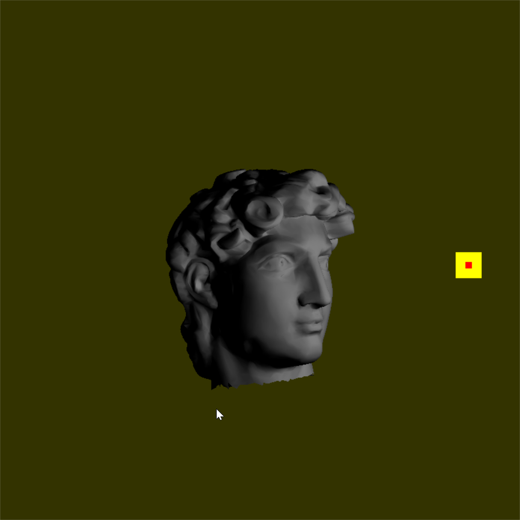

The same lgiht, viewed from the side

### 6. Placing the light according to shading

This time, the new light position should be chosen such that the light produces exactly a lambertian shading of zero at the clicked location. (Use the mode for toon shading to verify your solution). There are several possibilities to achieve this goal! The implicit condition is that $L \cdot N$ should be exactly zero at the clicked position, which leaves some degrees of freedom. Be sure to look at Figure 6 for an example.

**Implement the function `userInteractionShadow()` in `user_interaction.cpp`.**

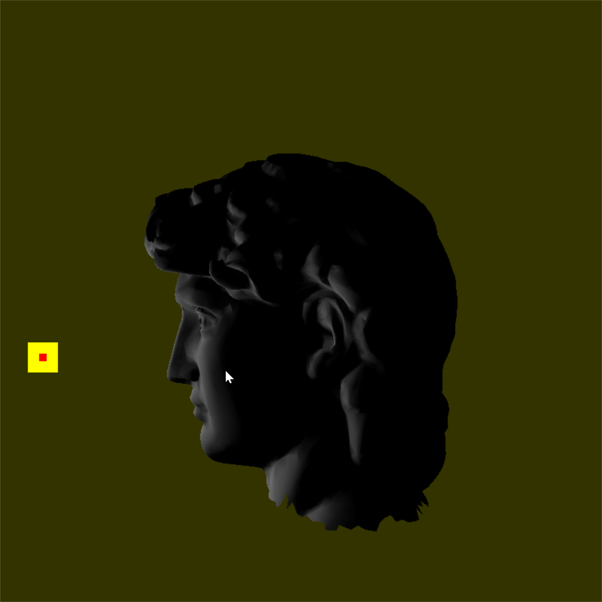

[figure not shown]

Placing the light according to shading

### 7. Placing the light based on specularities

This time, the new light position should be chosen such that the specularity is located exactly at the clicked location, when viewed from the current camera position. Remember, placing a specularity is not easy because its position depends on the view *AND* the light. Be sure to look at the final figure for an example.

**Implement the function `userInteractionSpecular()` in `user_interaction.cpp`.**

[figure not shown]

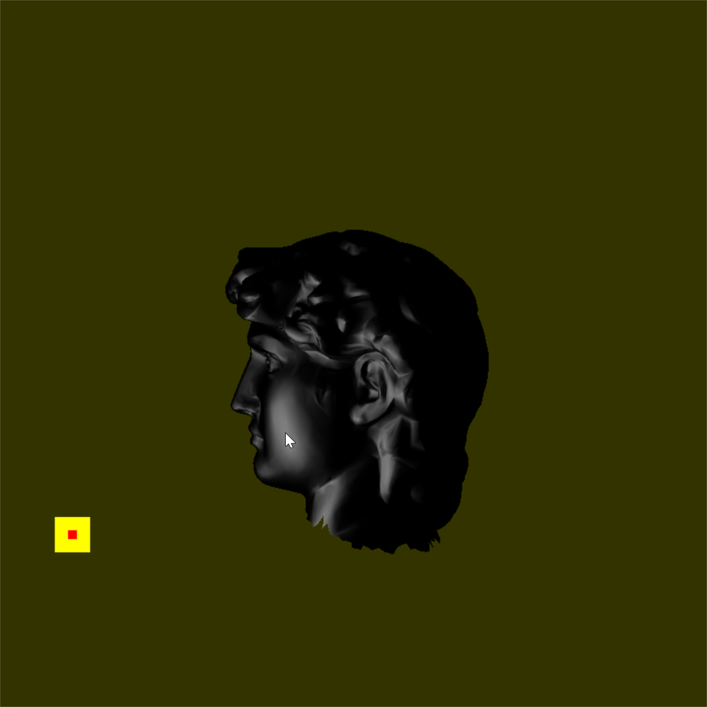

Placing the light based on specularities

## Submission

Your hand-ins will be automatically graded. For this system to work smoothly, we ask you to only hand in `shading.cpp` and `user_interaction.cpp`. Please **do not rename these files** and upload them directly to Brightspace (don’t put them in a zip/rar file).